# Лабораторная работа: Импорт и профилирование данных

Кильдибеков Данил Андреевич 02271-ДМ

# 1. Описание данных и цель

Цель — импортировать грязные наборы данных, привести типы, выявить проблемы качества и составить план очистки

# 2. Изучение сырого файла

```r
read_lines("data/raw/AirQualityUCI.csv", n_max = 5)
```

```
## [1] "Date;Time;CO(GT);PT08.S1(CO);NMHC(GT);C6H6(GT);PT08.S2(NMHC);NOx(GT);PT08.S3(NOx);NO2(GT);PT08.S4(NO2);PT08.S5(O3);T;RH;AH;;"
## [2] "10/03/2004;18.00.00;2,6;1360;150;11,9;1046;166;1056;113;1692;1268;13,6;48,9;0,7578;;"
## [3] "10/03/2004;19.00.00;2;1292;112;9,4;955;103;1174;92;1559;972;13,3;47,7;0,7255;;"
## [4] "10/03/2004;20.00.00;2,2;1402;88;9,0;939;131;1140;114;1555;1074;11,9;54,0;0,7502;;"
## [5] "10/03/2004;21.00.00;2,2;1376;80;9,2;948;172;1092;122;1584;1203;11,0;60,0;0,7867;;"
```

```r
read_lines("data/raw/AirQualityUCI.csv", skip = 9355)
```

```
##   [1] "04/04/2005;12.00.00;2,4;1142;-200;12,4;1063;293;603;175;1241;1092;26,9;18,3;0,6406;;"
##   [2] "04/04/2005;13.00.00;2,1;1003;-200;9,5;961;235;702;156;1041;770;28,3;13,5;0,5139;;"
##   [3] "04/04/2005;14.00.00;2,2;1071;-200;11,9;1047;265;654;168;1129;816;28,5;13,1;0,5028;;"
##   [4] ";;;;;;;;;;;;;;;;"
##   [5] ";;;;;;;;;;;;;;;;"
##   [6] ";;;;;;;;;;;;;;;;"
##   [7] ";;;;;;;;;;;;;;;;"
##   [8] ";;;;;;;;;;;;;;;;"
##   [9] ";;;;;;;;;;;;;;;;"
##  [10] ";;;;;;;;;;;;;;;;"
##  [11] ";;;;;;;;;;;;;;;;"
##  [12] ";;;;;;;;;;;;;;;;"
##  [13] ";;;;;;;;;;;;;;;;"
##  [14] ";;;;;;;;;;;;;;;;"
##  [15] ";;;;;;;;;;;;;;;;"
```

[output cut: 102 more lines]

```r
guess_encoding("data/raw/AirQualityUCI.csv")
```

```
## # A tibble: 1 × 2
##   encoding confidence
##   <chr>         <dbl>
## 1 ASCII             1
```

**Параметры файла**

| Параметр | Найденное значение | Чем подтверждено |
| --- | --- | --- |
| Разделитель полей | `;` | `read_lines(..., n_max = 5)` |
| Десятичный знак | `,` | значения вида `2,6` |
| Кодировка | ASCII | `guess_encoding()` |
| Служебные строки перед таблицей | нет, только 1 строка заголовка | `read_lines()` |
| Код пропуска | `-200` | значения `-200` в числовых столбцах |
| Пустые строки или столбцы в конце | есть | `read_lines(..., skip = 9355)` |

# 3. Импорт основного набора

```r
df_raw <- read_csv2(
  "data/raw/AirQualityUCI.csv",
  na = c("", "NA", "-200"),
  col_types = cols(
    Date = col_character(),
    Time = col_character(),
    .default = col_double()
  ),
  locale = locale(decimal_mark = ",", encoding = "UTF-8"),
  trim_ws = TRUE
)

glimpse(df_raw)
```

```
## Rows: 9,471
## Columns: 17
## $ Date            <chr> "10/03/2004", "10/03/2004", "10/03/2004", "10/03/2004"…
## $ Time            <chr> "18.00.00", "19.00.00", "20.00.00", "21.00.00", "22.00…
## $ `CO(GT)`        <dbl> 2.6, 2.0, 2.2, 2.2, 1.6, 1.2, 1.2, 1.0, 0.9, 0.6, NA, …
## $ `PT08.S1(CO)`   <dbl> 1360, 1292, 1402, 1376, 1272, 1197, 1185, 1136, 1094, …
## $ `NMHC(GT)`      <dbl> 150, 112, 88, 80, 51, 38, 31, 31, 24, 19, 14, 8, 16, 2…
## $ `C6H6(GT)`      <dbl> 11.9, 9.4, 9.0, 9.2, 6.5, 4.7, 3.6, 3.3, 2.3, 1.7, 1.3…
## $ `PT08.S2(NMHC)` <dbl> 1046, 955, 939, 948, 836, 750, 690, 672, 609, 561, 527…
## $ `NOx(GT)`       <dbl> 166, 103, 131, 172, 131, 89, 62, 62, 45, NA, 21, 16, 3…
## $ `PT08.S3(NOx)`  <dbl> 1056, 1174, 1140, 1092, 1205, 1337, 1462, 1453, 1579, …
## $ `NO2(GT)`       <dbl> 113, 92, 114, 122, 116, 96, 77, 76, 60, NA, 34, 28, 48…
## $ `PT08.S4(NO2)`  <dbl> 1692, 1559, 1555, 1584, 1490, 1393, 1333, 1333, 1276, …
## $ `PT08.S5(O3)`   <dbl> 1268, 972, 1074, 1203, 1110, 949, 733, 730, 620, 501, …
## $ T               <dbl> 13.6, 13.3, 11.9, 11.0, 11.2, 11.2, 11.3, 10.7, 10.7, …
## $ RH              <dbl> 48.9, 47.7, 54.0, 60.0, 59.6, 59.2, 56.8, 60.0, 59.7, …
## $ AH              <dbl> 0.7578, 0.7255, 0.7502, 0.7867, 0.7888, 0.7848, 0.7603…
## $ ...16           <dbl> NA, NA, NA, NA, NA, NA, NA, NA, NA, NA, NA, NA, NA, NA…
## $ ...17           <dbl> NA, NA, NA, NA, NA, NA, NA, NA, NA, NA, NA, NA, NA, NA…
```

```r
spec(df_raw)
problems(df_raw)
```

```
## # A tibble: 0 × 5
## # ℹ 5 variables: row <int>, col <int>, expected <chr>, actual <chr>, file <chr>
```

**Пояснение параметров:**

- `read_csv2()` — при использовании `read_csv()` запятая из десятичного разделителя превратилась бы в разделитель поля: все числа развалились бы на мусор, а `;` попал бы внутрь значений. `read_csv2()` заранее рассчитан на `;` + `,`
- `na = c("", "NA", "-200")` — без явного `-200` скрытый код пропуска попал бы в статистику как реальное значение и исказил бы `min`/`mean`/`sd`
- `Date = col_character()`, `Time = col_character()` — без них readr попытался бы распарсить `10/03/2004` и `18.00.00` автоматически, не угадал бы формат и превратил бы дату/время в `NA`
- `.default = col_double()` — без явного типа readr определил бы тип по первым строкам; если там `NA` или `-200`, тип мог бы стать `character`, и все числовые операции могли бы упасть
- `problems()` — без него не видно было бы, что импорт прошёл без ошибок парсинга

# 4. Файл с проблемной кодировкой

## 4.1. Чтение по умолчанию - «до»

```r
variant_file <- "data/raw/students.csv"

df_bad <- read_delim(variant_file, delim = ";", show_col_types = FALSE)
head(df_bad, 5)
```

```
## # A tibble: 5 × 5
##   `Ð¤Ð\u0098Ð\u009e`               Ð\u0093Ñ\u0080Ñ\u008…¹ Ð\u0094Ð¸Ñ\u0081Ñ\u0…²
##   <chr>                            <chr>                  <chr>
## 1 "Ð¡Ð¸Ð´Ð¾Ñ\u0080Ð¾Ð² Ð\u0090Ð½Ð… "Ð\u0098Ð\u0092Ð¢-21"  "Ð\u0090Ð½Ð°Ð»Ð¸Ð· Ð´…
## 2 "Ð\u009dÐ¸ÐºÐ¾Ð»Ð°ÐµÐ²Ð° Ð\u009… "Ð\u0098Ð\u0092Ð¢-21"  "Ð\u009cÐ°Ñ\u0082ÐµÐ¼…
## 3 "Ð\u009aÑ\u0083Ð·Ð½ÐµÑ\u0086Ð¾Ð… "Ð\u0098Ð\u0092Ð¢-21"  "Ð\u009cÐ°Ñ\u0088Ð¸Ð½…
## 4 "Ð\u009aÑ\u0083Ð·Ð½ÐµÑ\u0086Ð¾Ð… "Ð\u0098Ð\u0092Ð¢-22"  "Ð\u009cÐ°Ñ\u0088Ð¸Ð½…
## 5 "Ð\u0098Ð²Ð°Ð½Ð¾Ð² Ð\u009cÐ°Ñ\u… "Ð\u0098Ð\u0092Ð¢-22"  "Ð\u0090Ð½Ð°Ð»Ð¸Ð· Ð´…
## # ℹ abbreviated names: ¹`Ð\u0093Ñ\u0080Ñ\u0083Ð¿Ð¿Ð°`,
## #   ²`Ð\u0094Ð¸Ñ\u0081Ñ\u0086Ð¸Ð¿Ð»Ð¸Ð½Ð°`
## # ℹ 2 more variables: `Ð\u0091Ð°Ð»Ð»Ñ\u008b` <dbl>,
## #   `Ð\u009eÑ\u0086ÐµÐ½ÐºÐ°` <chr>
```

## 4.2. Диагностика

```r
readBin(variant_file, "raw", 12)
```

```
##  [1] c3 90 c2 a4 c3 90 c2 98 c3 90 c2 9e
```

```r
guess_encoding(variant_file)
```

```
## # A tibble: 1 × 2
##   encoding confidence
##   <chr>         <dbl>
## 1 UTF-8             1
```

- `readBin` - `c3 90 c2 a4 c3 90 c2 98 c3 90 c2 9e …`
- `guess_encoding` - UTF-8, confidence = 1

## 4.3. Чтение с подобранными `skip`/`comment` + восстановление

```r
df_fixed <- read_delim(
  variant_file,
  delim          = ";",
  skip           = 0,
  comment        = "",
  locale         = locale(encoding = "UTF-8"),
  show_col_types = TRUE
) %>%
  rename_with(fix_mojibake) %>%
  mutate(across(where(is.character), fix_mojibake))

names(df_fixed)
```

```
## [1] "ФИО"        "Группа"     "Дисциплина" "Баллы"      "Оценка"
```

```r
head(df_fixed, 5)
```

```
## # A tibble: 5 × 5
##   ФИО                            Группа Дисциплина                Баллы Оценка
##   <chr>                          <chr>  <chr>                     <dbl> <chr>
## 1 Сидоров Андрей Сергеевич       ИВТ-21 Анализ данных                69 удовлет…
## 2 Николаева Дмитрий Сергеевич    ИВТ-21 Математическая статистика    86 отлично
## 3 Кузнецова Екатерина Алексеевна ИВТ-21 Машинное обучение            85 отлично
## 4 Кузнецова Алексей Алексеевна   ИВТ-22 Машинное обучение            73 хорошо
## 5 Иванов Мария Петрович          ИВТ-22 Анализ данных                89 отлично
```

```r
glimpse(df_fixed)
```

```
## Rows: 36
## Columns: 5
## $ ФИО        <chr> "Сидоров Андрей Сергеевич", "Николаева Дмитрий Сергеевич", …
## $ Группа     <chr> "ИВТ-21", "ИВТ-21", "ИВТ-21", "ИВТ-22", "ИВТ-22", "ИВТ-22",…
## $ Дисциплина <chr> "Анализ данных", "Математическая статистика", "Машинное обу…
## $ Баллы      <dbl> 69, 86, 85, 73, 89, 55, 50, 64, 80, 56, 68, 58, 63, 51, 93,…
## $ Оценка     <chr> "удовлетворительно", "отлично", "отлично", "хорошо", "отлич…
```

```r
dim(df_fixed)
```

```
## [1] 36  5
```

`fix_mojibake()` в setup: `iconv(x, from = "UTF-8", to = "latin1")` + `Encoding(y) - "UTF-8"` — обратная операция к той, которой преобразовали данные в файле

## 4.4. Подобранные параметры

| Параметр | Значение | Чем подтверждено |
| --- | --- | --- |
| `delim` | `";"` | `read_lines(..., n_max = 1)` |
| `skip` | `0` | строка 1 — заголовок |
| `comment` | `""` | нет `#`-строк |
| `encoding` | `"UTF-8"` | `guess_encoding()` = UTF-8, 1; `readBin` — валидные UTF-8-байты |
| Размер | 36 × 5 | `dim(df_fixed)` |
| Типы | chr, chr, chr, dbl, chr | `glimpse(df_fixed)` |

**Вывод.** `delim`, `skip`, `comment` подобраны штатно. Подобрать `encoding` не удаётся, потому что файл дважды закодирован (mojibake). Кириллица восстановлена обратной операцией `fix_mojibake()`: 36 × 5

# 5. Имена, пустые строки и типы

```r
nrow_before <- nrow(df_raw)
ncol_before <- ncol(df_raw)

df <- df_raw %>%
  clean_names() %>%
  remove_empty(which = c("rows", "cols")) %>%
  mutate(
    time = str_replace_all(time, "\\.", ":"),
    datetime = parse_date_time(
      paste(date, time),
      orders = c("dmy HMS", "dmy HM"),
      tz = "Europe/Rome"
    )
  )

glimpse(df)
```

```
## Rows: 9,357
## Columns: 16
## $ date         <chr> "10/03/2004", "10/03/2004", "10/03/2004", "10/03/2004", "…
## $ time         <chr> "18:00:00", "19:00:00", "20:00:00", "21:00:00", "22:00:00…
## $ co_gt        <dbl> 2.6, 2.0, 2.2, 2.2, 1.6, 1.2, 1.2, 1.0, 0.9, 0.6, NA, 0.7…
## $ pt08_s1_co   <dbl> 1360, 1292, 1402, 1376, 1272, 1197, 1185, 1136, 1094, 101…
## $ nmhc_gt      <dbl> 150, 112, 88, 80, 51, 38, 31, 31, 24, 19, 14, 8, 16, 29, …
## $ c6h6_gt      <dbl> 11.9, 9.4, 9.0, 9.2, 6.5, 4.7, 3.6, 3.3, 2.3, 1.7, 1.3, 1…
## $ pt08_s2_nmhc <dbl> 1046, 955, 939, 948, 836, 750, 690, 672, 609, 561, 527, 5…
## $ n_ox_gt      <dbl> 166, 103, 131, 172, 131, 89, 62, 62, 45, NA, 21, 16, 34, …
## $ pt08_s3_n_ox <dbl> 1056, 1174, 1140, 1092, 1205, 1337, 1462, 1453, 1579, 170…
## $ no2_gt       <dbl> 113, 92, 114, 122, 116, 96, 77, 76, 60, NA, 34, 28, 48, 8…
## $ pt08_s4_no2  <dbl> 1692, 1559, 1555, 1584, 1490, 1393, 1333, 1333, 1276, 123…
## $ pt08_s5_o3   <dbl> 1268, 972, 1074, 1203, 1110, 949, 733, 730, 620, 501, 445…
## $ t            <dbl> 13.6, 13.3, 11.9, 11.0, 11.2, 11.2, 11.3, 10.7, 10.7, 10.…
## $ rh           <dbl> 48.9, 47.7, 54.0, 60.0, 59.6, 59.2, 56.8, 60.0, 59.7, 60.…
## $ ah           <dbl> 0.7578, 0.7255, 0.7502, 0.7867, 0.7888, 0.7848, 0.7603, 0…
## $ datetime     <dttm> 2004-03-10 18:00:00, 2004-03-10 19:00:00, 2004-03-10 20:…
```

```r
cat("До:", nrow_before, "×", ncol_before, " →  После:", nrow(df), "×", ncol(df), "\n")
```

```
## До: 9471 × 17  →  После: 9357 × 16
```

```r
sum(is.na(df$datetime))
```

```
## [1] 2
```

```r
df %>%
  filter(is.na(datetime)) %>%
  count(date, time, sort = TRUE)
```

```
## # A tibble: 2 × 3
##   date       time         n
##   <chr>      <chr>    <int>
## 1 27/03/2005 02:00:00     1
## 2 28/03/2004 02:00:00     1
```

**Имя до — имя после**

| До | После |
| --- | --- |
| `CO(GT)` | `co_gt` |
| `PT08.S1(CO)` | `pt08_s1_co` |
| `NMHC(GT)` | `nmhc_gt` |
| `C6H6(GT)` | `c6h6_gt` |
| `PT08.S2(NMHC)` | `pt08_s2_nmhc` |
| `NOx(GT)` | `n_ox_gt` |
| `PT08.S3(NOx)` | `pt08_s3_n_ox` |
| `NO2(GT)` | `no2_gt` |
| `PT08.S4(NO2)` | `pt08_s4_no2` |
| `PT08.S5(O3)` | `pt08_s5_o3` |
| `T` | `t` |
| `RH` | `rh` |
| `AH` | `ah` |

`sum(is.na(df$datetime)) = 2` — обе строки с датой `28/03/2004` и `27/03/2005` (переход на летнее время, из-за чего 02:00:00 не существует в Europe/Rome)

# 6. Профилирование

```r
skim(df)
```

Data summary

| Name | df |
| --- | --- |
| Number of rows | 9357 |
| Number of columns | 16 |
| _______________________ |  |
| Column type frequency: |  |
| character | 2 |
| numeric | 13 |
| POSIXct | 1 |
| ________________________ |  |
| Group variables | None |

**Variable type: character**

| skim_variable | n_missing | complete_rate | min | max | empty | n_unique | whitespace |
| --- | --- | --- | --- | --- | --- | --- | --- |
| date | 0 | 1 | 10 | 10 | 0 | 391 | 0 |
| time | 0 | 1 | 8 | 8 | 0 | 24 | 0 |

**Variable type: numeric**

| skim_variable | n_missing | complete_rate | mean | sd | p0 | p25 | p50 | p75 | p100 | hist |
| --- | --- | --- | --- | --- | --- | --- | --- | --- | --- | --- |
| co_gt | 1592 | 0.83 | -0.22 | 21.80 | -200.00 | 1.00 | 1.8 | 2.90 | 11.90 | ▁▁▁▁▇ |
| pt08_s1_co | 366 | 0.96 | 1099.83 | 217.08 | 647.00 | 937.00 | 1063.0 | 1231.00 | 2040.00 | ▃▇▃▁▁ |
| nmhc_gt | 8443 | 0.10 | 218.81 | 204.46 | 7.00 | 67.00 | 150.0 | 297.00 | 1189.00 | ▇▂▁▁▁ |
| c6h6_gt | 0 | 1.00 | 1.87 | 41.38 | -200.00 | 4.00 | 7.9 | 13.60 | 63.70 | ▁▁▁▇▅ |
| pt08_s2_nmhc | 366 | 0.96 | 939.15 | 266.83 | 383.00 | 734.50 | 909.0 | 1116.00 | 2214.00 | ▅▇▃▁▁ |
| n_ox_gt | 1639 | 0.82 | 246.90 | 212.98 | 2.00 | 98.00 | 180.0 | 326.00 | 1479.00 | ▇▂▁▁▁ |
| pt08_s3_n_ox | 366 | 0.96 | 835.49 | 256.82 | 322.00 | 658.00 | 806.0 | 969.50 | 2683.00 | ▇▇▁▁▁ |
| no2_gt | 1642 | 0.82 | 113.09 | 48.37 | 2.00 | 78.00 | 109.0 | 142.00 | 340.00 | ▃▇▃▁▁ |
| pt08_s4_no2 | 366 | 0.96 | 1456.26 | 346.21 | 551.00 | 1227.00 | 1463.0 | 1674.00 | 2775.00 | ▂▇▇▂▁ |
| pt08_s5_o3 | 366 | 0.96 | 1022.91 | 398.48 | 221.00 | 731.50 | 963.0 | 1273.50 | 2523.00 | ▃▇▅▂▁ |
| t | 366 | 0.96 | 18.32 | 8.83 | -1.90 | 11.80 | 17.8 | 24.40 | 44.60 | ▂▇▇▃▁ |
| rh | 366 | 0.96 | 49.23 | 17.32 | 9.20 | 35.80 | 49.6 | 62.50 | 88.70 | ▂▆▇▆▂ |
| ah | 366 | 0.96 | 1.03 | 0.40 | 0.18 | 0.74 | 1.0 | 1.31 | 2.23 | ▃▇▇▃▁ |

**Variable type: POSIXct**

| skim_variable | n_missing | complete_rate | min | max | median | n_unique |
| --- | --- | --- | --- | --- | --- | --- |
| datetime | 2 | 1 | 2004-03-10 18:00:00 | 2005-04-04 14:00:00 | 2004-09-21 16:00:00 | 9355 |

**Подозрительные диапазоны (по `skim()`):**

| Столбец | Что видно | Комментарий |
| --- | --- | --- |
| `co_gt` | min = -200, complete_rate = 0.83 | 1592 значения -200 заменены на NA при импорте, ещё 91 осталось (скорее всего записаны иначе); итого 1683 «плохих» значения |
| `c6h6_gt` | min = -200, complete_rate = 1.00 | 366 значений -200 все остались в данных — формат -200 не совпал с na = “-200” |
| `nmhc_gt` | `complete_rate = 0.0977` | 90 % пропусков — аномально много |
| `t` | `min = -1.9`, `max = 44.6` | диапазон широкий, но физически возможный |

```r
# Число отрицательных значений в столбцах
df %>%
  select(where(is.numeric)) %>%
  summarise(across(everything(), ~ sum(.x < 0, na.rm = TRUE))) %>%
  pivot_longer(everything(), names_to = "column", values_to = "n_negative") %>%
  filter(n_negative > 0)
```

```
## # A tibble: 3 × 2
##   column  n_negative
##   <chr>        <int>
## 1 co_gt           91
## 2 c6h6_gt        366
## 3 t               13
```

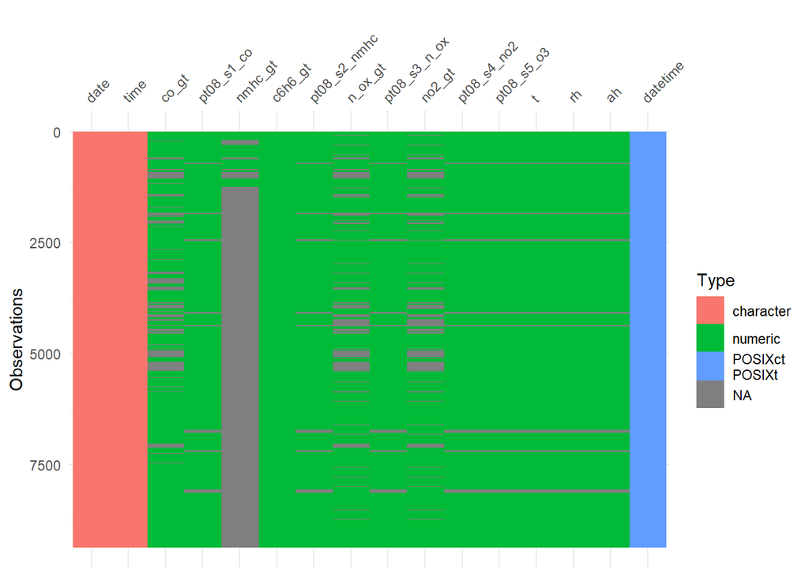

```r
vis_dat(df)
```

- `vis_dat()` показывает карту типов и пропусков
- Видно, что `nmhc_gt` почти полностью тёмный, что подтверждает `complete_rate = 0.0977`
- Остальные столбцы (кроме `co_gt`, `n_ox_gt`, `no2_gt`) заполнены равномерно
- Тип `POSIXct` у `datetime` отображается отдельно от `character` (`date`, `time`) и `numeric`

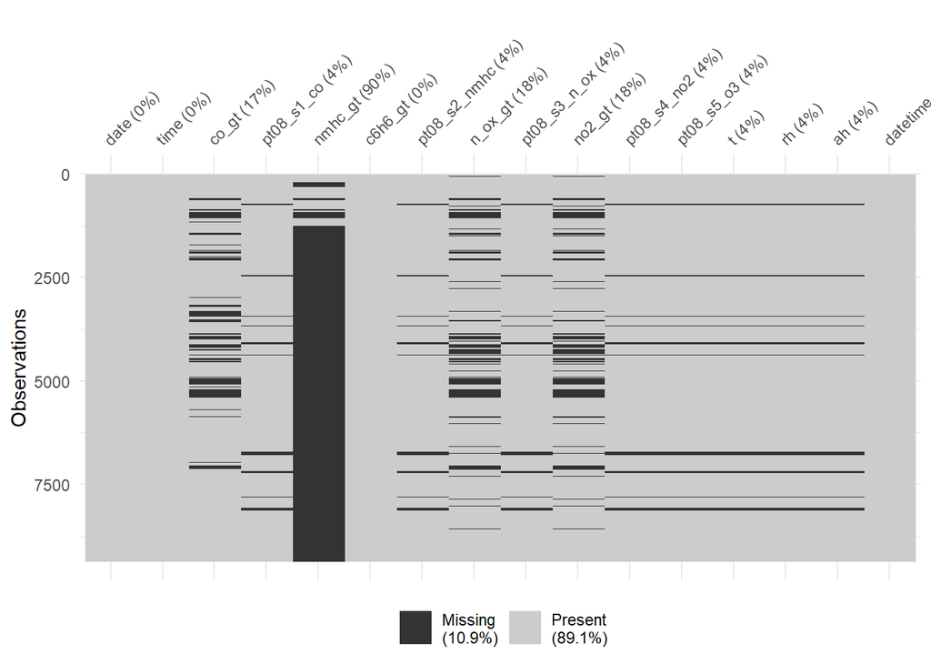

```r
vis_miss(df)
```

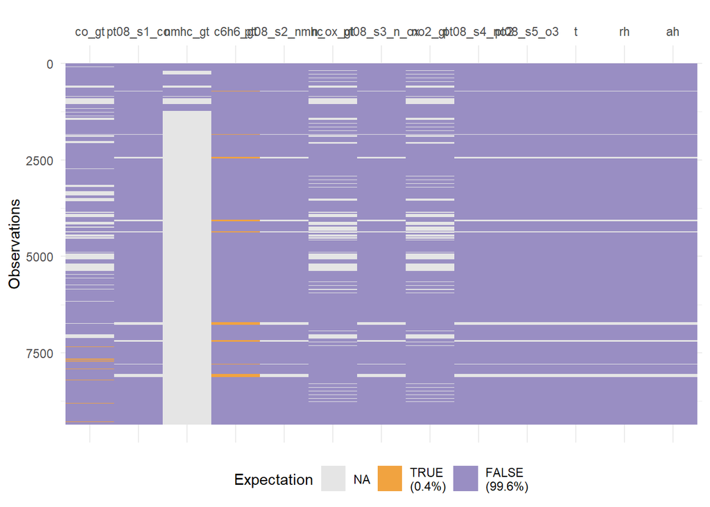

```r
num_df <- df %>% select(where(is.numeric))
vis_expect(num_df, ~ .x < 0)
```

`vis_expect(~ .x < 0)` подсвечивает три столбца: - co_gt (91 значение) и c6h6_gt (366) — остатки -200, не пойманные при импорте - t (13 значений) — температура, отрицательные значения приемлемы - Для концентраций отрицательные значения не приемлемы и требуют проверки источника

```r
create_report(df, output_file = "profile.html")
```

[output not shown]

[output not shown]

[output not shown]

[output not shown]

[output not shown]

[output not shown]

[output not shown]

[output not shown]

[output not shown]

`create_report()` сформировал автоматический отчёт `profile.html` со сводной статистикой, распределениями и корреляциями.

```r
get_dupes(df, datetime)
```

```
## # A tibble: 2 × 17
##   datetime dupe_count date       time     co_gt pt08_s1_co nmhc_gt c6h6_gt
##   <dttm>        <int> <chr>      <chr>    <dbl>      <dbl>   <dbl>   <dbl>
## 1 NA                2 28/03/2004 02:00:00   1.7       1135      95     6.3
## 2 NA                2 27/03/2005 02:00:00   1         1008      NA     3.3
## # ℹ 9 more variables: pt08_s2_nmhc <dbl>, n_ox_gt <dbl>, pt08_s3_n_ox <dbl>,
## #   no2_gt <dbl>, pt08_s4_no2 <dbl>, pt08_s5_o3 <dbl>, t <dbl>, rh <dbl>,
## #   ah <dbl>
```

`get_dupes()` показывает 2 строки, но обе с `datetime = NA` не реальные дубли меток времени, а те же 2 строки с некорректной датой из задания 5. Реальных дублей времени нет.

```r
count(df, date = as.Date(datetime), sort = TRUE) %>% head(10)
```

```
## # A tibble: 10 × 2
##    date           n
##    <date>     <int>
##  1 2004-03-11    24
##  2 2004-03-12    24
##  3 2004-03-13    24
##  4 2004-03-14    24
##  5 2004-03-15    24
##  6 2004-03-16    24
##  7 2004-03-17    24
##  8 2004-03-18    24
##  9 2004-03-19    24
## 10 2004-03-20    24
```

**Полнота по столбцам**

```r
skim(df) %>% select(skim_variable, n_missing, complete_rate)
```

```
## # A tibble: 16 × 3
##    skim_variable n_missing complete_rate
##    <chr>             <int>         <dbl>
##  1 datetime              2        1.000
##  2 date                  0        1
##  3 time                  0        1
##  4 co_gt              1592        0.830
##  5 pt08_s1_co          366        0.961
##  6 nmhc_gt            8443        0.0977
##  7 c6h6_gt               0        1
##  8 pt08_s2_nmhc        366        0.961
##  9 n_ox_gt            1639        0.825
## 10 pt08_s3_n_ox        366        0.961
## 11 no2_gt             1642        0.825
## 12 pt08_s4_no2         366        0.961
## 13 pt08_s5_o3          366        0.961
## 14 t                   366        0.961
## 15 rh                  366        0.961
## 16 ah                  366        0.961
```

[output not shown]

# 7. Чек-лист и план очистки

[output not shown]

**Вывод.** Наиболее серьёзны: 90 % пропусков в `nmhc_gt`, скрытые остатки `-200` в `co_gt` и `c6h6_gt` — они искажают статистику и графики Отдельная проблема — 2 строки с некорректной датой (летнее время), которые дают `NA` в `datetime` и «ложные дубли» в `get_dupes()` Отрицательные концентрации в `vis_expect()` — прямое следствие неполного перехвата `-200` Mojibake в файле студентов исправляется `fix_mojibake()`

# Контрольные вопросы

1. Проверял полноту (`skim()`, `vis_miss()`), типы и структуру (`glimpse()`, `vis_dat()`, `spec()`), валидность диапазонов (`skim()`, `vis_expect()`), уникальность (`get_dupes()`), согласованность даты/времени (`count()`, `parse_date_time`), кодировку (`guess_encoding()`, `readBin`), проблемы импорта (`problems()`).
2. `readr` угадывает тип по первым строкам; если там пропуски, коды вроде `-200` или пустые строки — тип может стать `character`. Надо явно задавать `col_types` и `na`.
3. Скрытые коды `-200` не распознаются как `NA`, портят `min`/`max`/`mean`/квантили, графики и модели.
4. `get_dupes()` только показывает дубликаты, потому что одинаковые строки не всегда ошибочны; решение об удалении зависит от контекста.
5. Нарушение tidy data — неверная форма (переменные в строках/столбцах, несколько значений в ячейке). Некорректное значение — ошибка содержания при правильной форме.